# Lista 4 - EAD - Introdução ao Python

Grupo:

- Carina Esteves
- Joaquim
- Matheus Guim
- Polyanna Figueiredo

## Descrição

Para o presente trabalho, utilizamos um data set com diversas informações acerca do mercado cinematográfico nos últimos anos. A partir disso, elaboramos uma análise exploratória dos dados, a fim de entender os principais aspectos desse mercado.

Abaixo apresentamos algumas características do data set:

```python
import pandas as pd
import numpy as np
import matplotlib.pyplot as plt
import seaborn as sns

from nltk.probability import FreqDist
from scipy.stats import spearmanr

sns.set_style("white")
%matplotlib inline
```

## Colunas do Data Set

Abaixo podemos visualizar as colunas do data set. São 28 colunas que caracterizam cada um dos filmes (que são as linhas). As colunas têm nome, quantidade de filmes descritos nela, a obrigação de ser não-nula e o tipo de dado (inteiro, float, objeto).

```python
imdb = pd.read_csv(r"C:\Users\Joaquim\Desktop\Nova pasta\movie_metadata.csv")
imdb.info()
```

```
<class 'pandas.core.frame.DataFrame'>
RangeIndex: 5043 entries, 0 to 5042
Data columns (total 28 columns):
color                        5025 non-null object
director_name                4872 non-null object
num_critic_for_reviews       4927 non-null float64
duration                     4959 non-null float64
director_facebook_likes      4872 non-null float64
actor_3_facebook_likes       4953 non-null float64
actor_2_name                 4963 non-null object
actor_1_facebook_likes       4968 non-null float64
gross                        4104 non-null float64
genres                       4974 non-null object
actor_1_name                 4968 non-null object
movie_title                  4974 non-null object
num_voted_users              4974 non-null float64
cast_total_facebook_likes    4974 non-null float64
actor_3_name                 4953 non-null object
facenumber_in_poster         4961 non-null float64
plot_keywords                4827 non-null object
movie_imdb_link              4974 non-null object
num_user_for_reviews         4956 non-null float64
language                     4963 non-null object
country                      4971 non-null object
content_rating               4677 non-null object
budget                       4494 non-null float64
title_year                   4869 non-null float64
actor_2_facebook_likes       4963 non-null float64
imdb_score                   4974 non-null float64
aspect_ratio                 4654 non-null float64
movie_facebook_likes;        4974 non-null object
dtypes: float64(15), object(13)
memory usage: 1.1+ MB
```

```python
imdb.head()
```

|  | color | director_name | num_critic_for_reviews | duration | director_facebook_likes | actor_3_facebook_likes | actor_2_name | actor_1_facebook_likes | gross | genres | ... | num_user_for_reviews | language | country | content_rating | budget | title_year | actor_2_facebook_likes | imdb_score | aspect_ratio | movie_facebook_likes; |
| --- | --- | --- | --- | --- | --- | --- | --- | --- | --- | --- | --- | --- | --- | --- | --- | --- | --- | --- | --- | --- | --- |
| 0 | Color | James Cameron | 723.0 | 178.0 | 0.0 | 855.0 | Joel David Moore | 1000.0 | 760505847.0 | Action\|Adventure\|Fantasy\|Sci-Fi | ... | 3054.0 | English | USA | PG-13 | 237000000.0 | 2009.0 | 936.0 | 7.9 | 1.78 | 33000; |
| 1 | Color | Gore Verbinski | 302.0 | 169.0 | 563.0 | 1000.0 | Orlando Bloom | 40000.0 | 309404152.0 | Action\|Adventure\|Fantasy | ... | 1238.0 | English | USA | PG-13 | 300000000.0 | 2007.0 | 5000.0 | 7.1 | 2.35 | 0; |
| 2 | Color | Sam Mendes | 602.0 | 148.0 | 0.0 | 161.0 | Rory Kinnear | 11000.0 | 200074175.0 | Action\|Adventure\|Thriller | ... | 994.0 | English | UK | PG-13 | 245000000.0 | 2015.0 | 393.0 | 6.8 | 2.35 | 85000; |
| 3 | Color | Christopher Nolan | 813.0 | 164.0 | 22000.0 | 23000.0 | Christian Bale | 27000.0 | 448130642.0 | Action\|Thriller | ... | 2701.0 | English | USA | PG-13 | 250000000.0 | 2012.0 | 23000.0 | 8.5 | 2.35 | 164000; |
| 4 | NaN | Doug Walker | NaN | NaN | 131.0 | NaN | Rob Walker | 131.0 | NaN | Documentary | ... | NaN | NaN | NaN | NaN | NaN | NaN | 12.0 | 7.1 | NaN | 0; |

5 rows × 28 columns

## Data Integrity

A seguir temos o total de valores nulos por coluna.

```python
imdb.isna().sum(axis=0)
```

```
color                         18
director_name                171
num_critic_for_reviews       116
duration                      84
director_facebook_likes      171
actor_3_facebook_likes        90
actor_2_name                  80
actor_1_facebook_likes        75
gross                        939
genres                        69
actor_1_name                  75
movie_title                   69
num_voted_users               69
cast_total_facebook_likes     69
actor_3_name                  90
facenumber_in_poster          82
plot_keywords                216
movie_imdb_link               69
num_user_for_reviews          87
language                      80
country                       72
content_rating               366
budget                       549
title_year                   174
actor_2_facebook_likes        80
imdb_score                    69
aspect_ratio                 389
movie_facebook_likes;         69
dtype: int64
```

```python
imdb = imdb[~imdb.duplicated()] # Removendo linhas duplicadas
```

## Exploratory Data Analysis

A partir da matriz de correlação abaixo, observamos que existe uma forte correlação entre as variáveis "num_voted_users" e "num_user_for_review". O que faz sentido, já que quanto mais usuários votando em um certo filme, maior será a quantidade de usuários por review.

É interessante destacar a correlação moderada entre o faturamente bruto (gross) e o número de usuários que votou (num_voted_users). Isso siginifica que em média, os filmes que possuem um faturamente bruto maior, recebem uma maior quantidade de votos.

Outro ponto interessante, é que não existe nenhuma correlação forte entre o faturamento bruto (groos) e o orçamento gasto no filme (budget). Assim, não necessariamente um filme que houve maior gasto em orçamento, terá um maior faturamento no mercado.

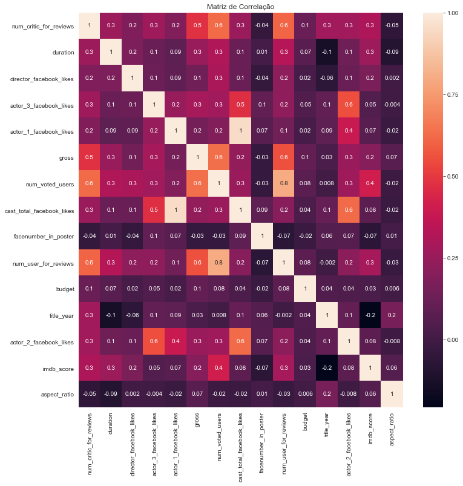

```python
plt.figure(figsize=(12, 12))
sns.heatmap(imdb.corr().T, annot=True, fmt='.1g')
plt.title('Matriz de Correlação');
```

```python
imdb['profit'] = imdb['gross'] - imdb['budget']
imdb['return_on_investment'] = (imdb['profit'] / imdb['budget']) * 100
```

## Quais os 10 filmes mais lucrativos?

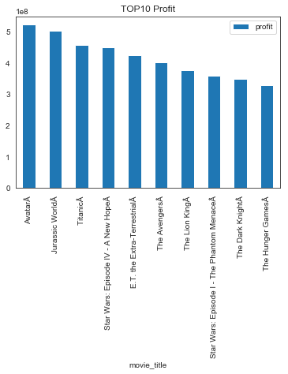

```python
imdb.sort_values('profit', ascending=False).head(10).plot.bar(x='movie_title', y='profit');
plt.title('TOP10 Profit');
```

## Retorno sobre Investimento

Já quando analisamos o retorno do investimento, Atividade Paranormal aparece em primeiro lugar. Isso siginifca que esses filmes conseguiram um bom retorno financeiro comparado ao budget do filme.

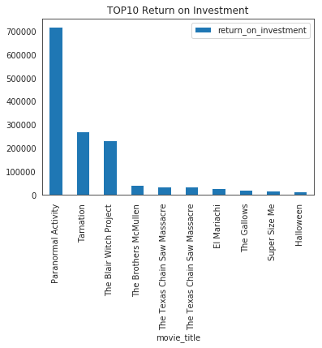

```python
imdb.sort_values('return_on_investment', ascending=False).head(10).plot.bar(x='movie_title', y='return_on_investment');
plt.title('TOP10 Return on Investment');
```

## Sucesso de Crítica x Sucesso Comercial por conteúdo

Percebemos que os filmes com maior faturamento e nota no IMDB são da categoria PG-13.

```python
top_profit = imdb.sort_values('profit', ascending=False).head(100)
```

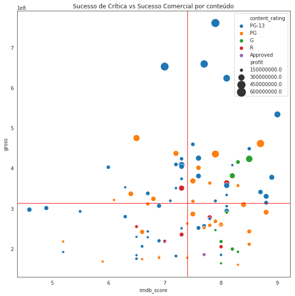

```python
plt.figure(figsize=(10, 10))
sns.scatterplot(x='imdb_score', y='gross', size='profit', hue='content_rating',
                sizes=(30, 300),data=top_profit)
plt.axvline(linewidth=1, color='r', x=top_profit.imdb_score.mean())
plt.axhline(linewidth=1, color='r', y=top_profit.gross.mean())
plt.title('Sucesso de Crítica vs Sucesso Comercial por conteúdo');
```

## Filme preto e branco ou em cor?

A Era de Ouro do Cinema Americano é conhecido como a época dos filmes hollywoodianos produzidos de 1920 a 1960 onde a maioria dos filmes eram preto e branco. Podemos observar essa era através do gráfico acima, onde a partir dos anos 1960 a representatividade de filmes preto e branco no mercado cai consideravelmente. É interessante notar que durante as décadas de 1970 e 1980 praticamente não houve nenhum filme em preto branco porém, nos anos 1990 e 2000 eles crescem substancialmente e voltam a cair na última década. Curiosamente, O Artista, filme em P&B, ganhou o Óscar em 2012.

```python
imdb['title_decade'] = imdb['title_year'] - imdb['title_year'] % 10
color_decade = imdb.groupby(['title_decade', 'color']).size().reset_index()
color_decade.columns = ['title_decade', 'color', 'N']
```

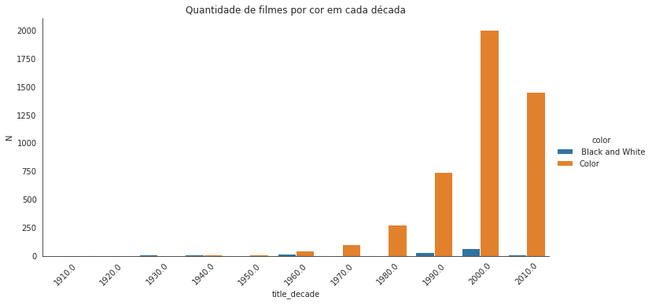

```python
g = sns.catplot(y='N', hue='color', x='title_decade', data=color_decade, kind="bar", height=5, aspect=2)
plt.xticks(rotation=45)
plt.title('Quantidade de filmes por cor em cada década');
```

## Quais os diretores com maior número de filmes?

Steven Spielberg é o Diretor com maior representatividade em relação à quantidade de filmes desenvolvidos, seguido por Woody Allen.

Podemos observar, no entanto, que a quantidade de filmes por diretor é distribuida de forma bem heterogênea.

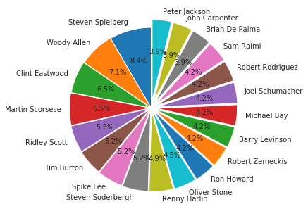

```python
x = pd.value_counts(imdb['director_name'])
cat = x[:20].index.values
freq = x[:20].values

np.append(cat, 'Others')
np.append(freq, np.sum(x[20:]))

plt.figure(figsize=(6,6))
plt.pie(freq, labels=cat, explode=np.linspace(0,0.1,20),startangle=90,autopct='%1.1f%%')
#plt.show()
plt.tight_layout()
```

## Qual o orçamento dos filmes?

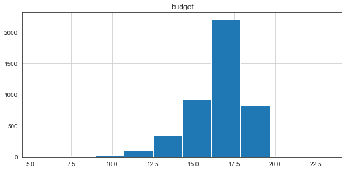

```python
np.log(imdb[['budget']]).hist(figsize=(8,4))
#plt.show()
plt.tight_layout()
plt.savefig('hist.pdf', dpi=300, format='pdf')
```

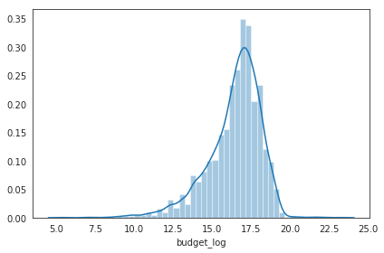

```python
imdb['budget_log'] = np.log(imdb['budget'])
sns.distplot(imdb['budget_log'].dropna())
#plt.show()
plt.tight_layout()
plt.savefig('dist.pdf', dpi=300, format='pdf')
```

## Qual a relação entre o orçamento de um filme e a sua nota no IMDB?

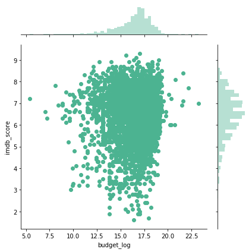

```python
sns.jointplot('budget_log', 'imdb_score', color="#4CB391", data=imdb)
#plt.show()

plt.tight_layout()
plt.savefig('joint.jpg', dpi=300, format='jpg')
```

## TOP10 diretores com maiores scores no IMDB

Observamos pelos gráficos abaixo que o diretor com melhor nota no IMDB é John Blanchard.

[figure not shown]

```python
# TOP10 diretores com maiores scores no IMDB

top_director = imdb.groupby('director_name').imdb_score.mean().sort_values(ascending=False).iloc[:10]
top_director.plot.bar(title='TOP 10 diretores IMDB score médio');
```

## Quantidade de filmes por gênero

```python
imdb['genres'] = imdb.genres.str.split('|')

genres = (imdb[['genres']]
          .apply(lambda x: x.apply(pd.Series).stack())
          .drop_duplicates())

genres = list(genres.genres)

for genre in genres:
  imdb[genre] = imdb[['genres']].applymap(lambda movie: genre in movie) # Criando variaveis binarias para cada genero
```

```python
top_genre = imdb.groupby('director_name').imdb_score.mean().sort_values(ascending=False).iloc[:10]
top_director.plot.bar(title='TOP 10 diretores IMDB score médio');
imdb.loc[:, 'Action':'Film-Noir'].sum().sort_values(ascending=False).plot.bar(title='Filmes por genero')
```

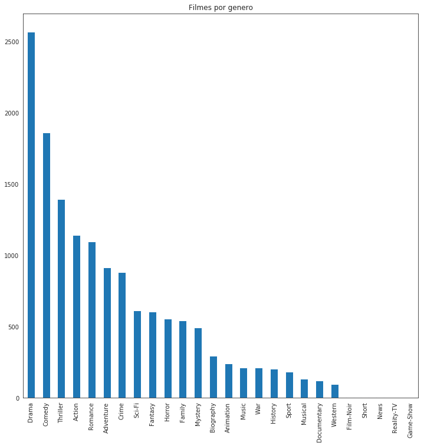

```python
plt.figure(figsize=(12, 12))
imdb.loc[:, 'Action':'Film-Noir'].sum().sort_values(ascending=False).plot.bar(title='Filmes por genero');
```

## Qual é a relação entre orçamento e lucro?

Percebe-se pelo gráfico a seguir uma relação linear entre orçamento e lucro.

[figure not shown]

```python
finance_info = imdb[['movie_title', 'profit', 'budget']].dropna()
finance_info = finance_info.query('profit != 0 & budget != 0')
finance_info[['profit', 'budget']] = finance_info[['profit', 'budget']].apply(np.log10)

g = sns.jointplot('profit', 'budget', finance_info, stat_func=spearmanr, kind='reg', height=10)
g.set_axis_labels('log(Budget)', 'log(Profit)')
plt.title('Regressão Linear');
```

## Quais as palavras-chave que mais aparecem

Amor, amigo, assassinato, morte e polícia são, nesta ordem, as 5 palavras-chave mais frequentes.

```python
plot_keywords = [word for wordlist in keywords.plot_keywords.str.split('|') for word in wordlist]
frequency_dist = FreqDist(plot_keywords)
```

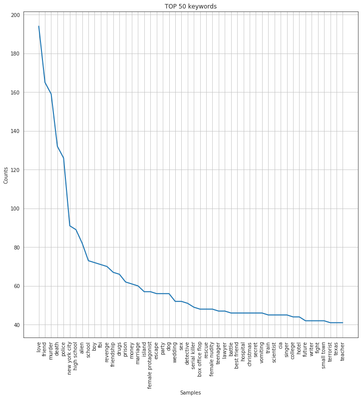

```python
plt.figure(figsize=(12, 12))
frequency_dist.plot(50, cumulative=False, title='TOP 50 keywords')
```